Analysis of Happiness in the World From 2015-2019

Alex Xiao and Henrique Corte

# Outline:

```
1. Introduction
    1.1 Motivation
    1.2 Libraries Used
2. Data Collection
3. Data management/representation
4. Data Analysis and Visualization
5. Hypothesis testing and machine learning
6. Conclusions
```

# 1. Introduction

```
1.1 Motivation:
    Happiness appears to be an increasingly important factor to our existence. People have begun to embrace being happy as a concept in it of itself. As we begin to optimize and desire more of this intangible qualia, we as a species have begun to categorize and break "happiness" down into what appears to be relevant components in a desire to further our understanding. While there are many individualistic things one can do to improve their happiness such as practicing meditation and gratefulness, and a whole host of new research and media centered around happiness, this tutorial will attempt to examine larger nation-wide factors that can impact happiness.

1.2 Libraries Used:
    Pandas: used to represent and see data in dataframes
    Matplotlib: used generate data plots
    SKLearn: used to analyze data and predict factors
    Numpy: used to support data and pandas
    Statistics: more generalized statistical methods
    Scipy: used for some statistical analysis
    Statsmodels: used for additional statistical analysis
    Seaborn: used for additional data visualization
    Folium + Requests: used for mapping
```

```python
import pandas as pd
import matplotlib.pyplot as plt
from sklearn.linear_model import LinearRegression
from sklearn import linear_model
import numpy as np
import statistics
import scipy
import statsmodels.api as sm
import seaborn as sn
import folium
import requests
```

# 2.Data Collection

The source of the data is: https://www.kaggle.com/unsdsn/world-happiness . The individual CSV's for each year were locally downloaded and then imported via pandas The coordinate data (to map locations) is from here: https://www.kaggle.com/paultimothymooney/latitude-and-longitude-for-every-country-and-state . (Also locally downloaded and imported via pandas)

```python
data_15 = pd.read_csv('2015.csv', sep=',')
data_16 = pd.read_csv('2016.csv', sep=',')
data_17 = pd.read_csv('2017.csv', sep=',')
data_18 = pd.read_csv('2018.csv', sep=',')
data_19 = pd.read_csv('2019.csv', sep=',')
locations = pd.read_csv("world_country_and_usa_states_latitude_and_longitude_values.csv")
```

# 3. Data Management/Representation

```
The data from Kaggle is kind enough to provide a quick-preview. It appears that each year's data set is non-homogenous. Let's try to get them all uniform for more easy comparisons. The more recent data from 2018/2019 formats seem to be more concise and make more sense than previous years. Extraneous data will be ignored and there will be a focus on GDP, Social Support, Life Expectancy, Freedom, Generosity, and Perception of Governmental Corruption.
```

```python
col_names = ['Overall Rank', 'Country or Region', 'Score', 'GDP per capita', 'Social Support',
            'Healthy Life Expectancy', 'Freedom to Make Life Choices', 'Generosity', 'Perceptions of Corruption']
```

```python
data_15.head(1)
```

|  | Country | Region | Happiness Rank | Happiness Score | Standard Error | Economy (GDP per Capita) | Family | Health (Life Expectancy) | Freedom | Trust (Government Corruption) | Generosity | Dystopia Residual |
| --- | --- | --- | --- | --- | --- | --- | --- | --- | --- | --- | --- | --- |
| 0 | Switzerland | Western Europe | 1 | 7.587 | 0.03411 | 1.39651 | 1.34951 | 0.94143 | 0.66557 | 0.41978 | 0.29678 | 2.51738 |

This looks a little messy, let's start cleaning it up. We will drop the non-conforming columns, normalize all the column names, and make sure all the data is in the same position across all the tables. Let's also add the year into a new column just in case.

```python
data_15 = data_15.drop(columns=['Region', 'Standard Error', 'Dystopia Residual'])
data_15.columns = ['Country or Region', 'Overall Rank', 'Score', 'GDP per capita', 'Social Support', 'Healthy Life Expectancy',
                 'Freedom to Make Life Choices', 'Perceptions of Corruption', 'Generosity']
data_15 = data_15.reindex(columns = col_names)
data_15['Year'] = 2015
data_15.head(1)
```

|  | Overall Rank | Country or Region | Score | GDP per capita | Social Support | Healthy Life Expectancy | Freedom to Make Life Choices | Generosity | Perceptions of Corruption | Year |
| --- | --- | --- | --- | --- | --- | --- | --- | --- | --- | --- |
| 0 | 1 | Switzerland | 7.587 | 1.39651 | 1.34951 | 0.94143 | 0.66557 | 0.29678 | 0.41978 | 2015 |

That's better, let's do the same for the rest of the data sets.

```python
data_16.head(1)
```

|  | Country | Region | Happiness Rank | Happiness Score | Lower Confidence Interval | Upper Confidence Interval | Economy (GDP per Capita) | Family | Health (Life Expectancy) | Freedom | Trust (Government Corruption) | Generosity | Dystopia Residual |
| --- | --- | --- | --- | --- | --- | --- | --- | --- | --- | --- | --- | --- | --- |
| 0 | Denmark | Western Europe | 1 | 7.526 | 7.46 | 7.592 | 1.44178 | 1.16374 | 0.79504 | 0.57941 | 0.44453 | 0.36171 | 2.73939 |

```python
data_16 = data_16.drop(columns=['Region', 'Lower Confidence Interval', 'Upper Confidence Interval', 'Dystopia Residual'])
data_16.columns = ['Country or Region', 'Overall Rank', 'Score', 'GDP per capita', 'Social Support', 'Healthy Life Expectancy',
                 'Freedom to Make Life Choices', 'Perceptions of Corruption', 'Generosity']
data_16 = data_16.reindex(columns = col_names)
data_16['Year'] = 2016
data_16.head(1)
```

|  | Overall Rank | Country or Region | Score | GDP per capita | Social Support | Healthy Life Expectancy | Freedom to Make Life Choices | Generosity | Perceptions of Corruption | Year |
| --- | --- | --- | --- | --- | --- | --- | --- | --- | --- | --- |
| 0 | 1 | Denmark | 7.526 | 1.44178 | 1.16374 | 0.79504 | 0.57941 | 0.36171 | 0.44453 | 2016 |

```python
data_17.head(1)
```

|  | Country | Happiness.Rank | Happiness.Score | Whisker.high | Whisker.low | Economy..GDP.per.Capita. | Family | Health..Life.Expectancy. | Freedom | Generosity | Trust..Government.Corruption. | Dystopia.Residual |
| --- | --- | --- | --- | --- | --- | --- | --- | --- | --- | --- | --- | --- |
| 0 | Norway | 1 | 7.537 | 7.594445 | 7.479556 | 1.616463 | 1.533524 | 0.796667 | 0.635423 | 0.362012 | 0.315964 | 2.277027 |

```python
data_17 = data_17.drop(columns=['Whisker.high', 'Whisker.low', 'Dystopia.Residual'])
data_17.columns = ['Country or Region', 'Overall Rank', 'Score', 'GDP per capita', 'Social Support', 'Healthy Life Expectancy',
                 'Freedom to Make Life Choices', 'Generosity', 'Perceptions of Corruption']
data_17 = data_17.reindex(columns = col_names)
data_17['Year'] = 2017
data_17.head(1)
```

|  | Overall Rank | Country or Region | Score | GDP per capita | Social Support | Healthy Life Expectancy | Freedom to Make Life Choices | Generosity | Perceptions of Corruption | Year |
| --- | --- | --- | --- | --- | --- | --- | --- | --- | --- | --- |
| 0 | 1 | Norway | 7.537 | 1.616463 | 1.533524 | 0.796667 | 0.635423 | 0.362012 | 0.315964 | 2017 |

```python
data_18.head(1)
```

|  | Overall rank | Country or region | Score | GDP per capita | Social support | Healthy life expectancy | Freedom to make life choices | Generosity | Perceptions of corruption |
| --- | --- | --- | --- | --- | --- | --- | --- | --- | --- |
| 0 | 1 | Finland | 7.632 | 1.305 | 1.592 | 0.874 | 0.681 | 0.202 | 0.393 |

```python
data_18.columns = ['Overall Rank', 'Country or Region', 'Score', 'GDP per capita', 'Social Support', 'Healthy Life Expectancy',
                 'Freedom to Make Life Choices', 'Generosity', 'Perceptions of Corruption']
data_18 = data_18.reindex(columns = col_names)
data_18['Year'] = 2018
data_18.head(1)
```

|  | Overall Rank | Country or Region | Score | GDP per capita | Social Support | Healthy Life Expectancy | Freedom to Make Life Choices | Generosity | Perceptions of Corruption | Year |
| --- | --- | --- | --- | --- | --- | --- | --- | --- | --- | --- |
| 0 | 1 | Finland | 7.632 | 1.305 | 1.592 | 0.874 | 0.681 | 0.202 | 0.393 | 2018 |

```python
data_19.head(1)
```

|  | Overall rank | Country or region | Score | GDP per capita | Social support | Healthy life expectancy | Freedom to make life choices | Generosity | Perceptions of corruption |
| --- | --- | --- | --- | --- | --- | --- | --- | --- | --- |
| 0 | 1 | Finland | 7.769 | 1.34 | 1.587 | 0.986 | 0.596 | 0.153 | 0.393 |

```python
data_19.columns = ['Overall Rank', 'Country or Region', 'Score', 'GDP per capita', 'Social Support', 'Healthy Life Expectancy',
                 'Freedom to Make Life Choices', 'Generosity', 'Perceptions of Corruption']
data_19 = data_19.reindex(columns = col_names)
data_19['Year'] = 2019
data_19.head(1)
```

|  | Overall Rank | Country or Region | Score | GDP per capita | Social Support | Healthy Life Expectancy | Freedom to Make Life Choices | Generosity | Perceptions of Corruption | Year |
| --- | --- | --- | --- | --- | --- | --- | --- | --- | --- | --- |
| 0 | 1 | Finland | 7.769 | 1.34 | 1.587 | 0.986 | 0.596 | 0.153 | 0.393 | 2019 |

To give a quick explanation of the data:

1. Overall Rank: of the countries surveyed, which has the highest happiness score, and therefore, its happiness rank
2. Country or Region: self-explanatory, which country was surveyed
3. GDP per capita: a relative scaled measurement of the economic might of the country per person (how much "stuff" a country outputs relative to its population)
4. Social Support: a relative scaled measurement of how much the people surveyed felt supported by family and friends
5. Healthy Life Expectancy: a relative scaled measurement of the average life expectancy of an individual (from natural causes, excluding accidents etc.)
6. Freedom to Make Life Choices: a relative scaled measurement of ability to decide things in life
7. Generosity: a relative scaled measurement of how generous people are (with donations and such)
8. Perceptions of Corruption: a relative scaled measurement of how corrupt people think their government is

Now that we have the data normalized, let us begin looking for discernible patterns. Let's create a heatmap of the dataframes to see if anything obvious appears.

# 4. Data Analysis and Visualization

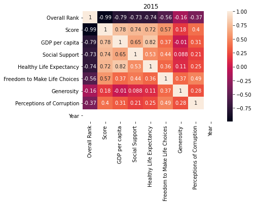

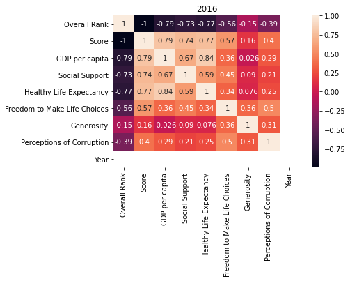

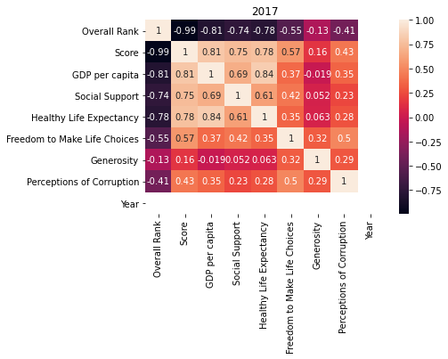

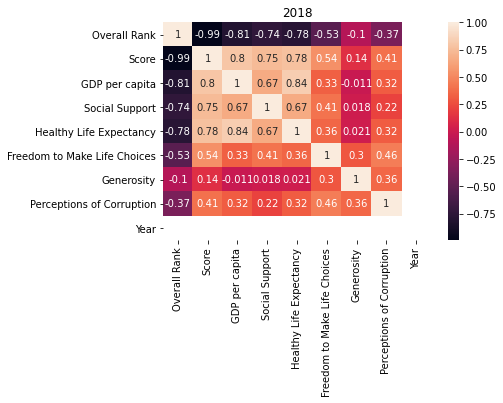

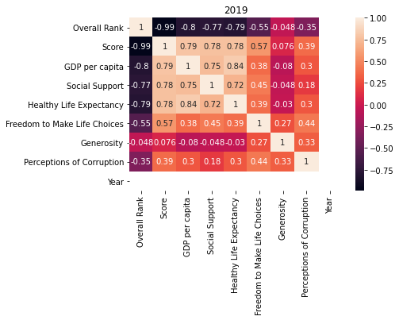

```python
Years = [2015, 2016, 2017, 2018, 2019]
dataframes = [data_15, data_16, data_17, data_18, data_19]

for i,y in zip(dataframes, Years):
    correlation = i.corr()
    sn.heatmap(correlation, annot = True)
    plt.title(y)
    plt.show()
```

From the heatmaps indicating correlation, it's quite clear that most things have a positive correlation with regards to the Happiness Score. Not surprisingly, GDP per capita, social support, life expectancy, freedom, and perception of lower governmental corruption are all correlated with feeling happy. What is surprising is generosity has the least correlation with happiness of all the other factors and is GDP agnostic-as in everyone has similar levels of generosity. GDP per capita, Social Support, and Healthy Life Expectancy all look very similar w.r.t. correlation to Happiness Score though.

Let's map out the top 25 happiest countries and 25 least happy countries to see if there are any more things to be gleaned.

```python
locations.head(1)
```

|  | country_code | latitude | longitude | country | usa_state_code | usa_state_latitude | usa_state_longitude | usa_state |
| --- | --- | --- | --- | --- | --- | --- | --- | --- |
| 0 | AD | 42.546245 | 1.601554 | Andorra | AK | 63.588753 | -154.493062 | Alaska |

The dataset is US-centered, and we only care about countries in aggregate. Let's drop the unnecessary columns.

```python
locations = locations.drop(columns = ['country_code', 'usa_state_code', 'usa_state_latitude', 'usa_state_longitude', 'usa_state'])
```

```python
locations.head(1)
```

|  | latitude | longitude | country |
| --- | --- | --- | --- |
| 0 | 42.546245 | 1.601554 | Andorra |

```python
for df, year in zip(dataframes, Years):
    print('countries: ' + str(df.shape[0]), 'year: ' + str(year))
```

```
countries: 158 year: 2015
countries: 157 year: 2016
countries: 155 year: 2017
countries: 156 year: 2018
countries: 156 year: 2019
```

Let's check how many countries were surveyed each year. About 155 each year.

```python
map_osm = folium.Map(location=[54.53, 17.25], zoom_start=2)
#arbitrary cutoffs from 105-155
for i, row in data_15.iterrows():
    if (row['Overall Rank'] <= 25):
        if(row['Country or Region'] in locations.values):
            lat = locations.loc[locations['country'] == row['Country or Region'], 'latitude']
            lon = locations.loc[locations['country'] == row['Country or Region'], 'longitude']
            folium.Marker(
                location = [float(lat),float(lon)],
                popup = "{}".format(row['Country or Region']),
                icon = folium.Icon(color="blue"),
            ).add_to(map_osm)
    if (row['Overall Rank'] >= 130):
        if(row['Country or Region'] in locations.values):
            lat = locations.loc[locations['country'] == row['Country or Region'], 'latitude']
            lon = locations.loc[locations['country'] == row['Country or Region'], 'longitude']
            folium.Marker(
                location = [float(lat),float(lon)],
                popup = "{}".format(row['Country or Region']),
                icon = folium.Icon(color="red"),
            ).add_to(map_osm)

map_osm
```

Make this Notebook Trusted to load map: File -> Trust Notebook

[interactive chart not shown]

```python
map_osm = folium.Map(location=[54.53, 17.25], zoom_start=2)
#arbitrary cutoffs from 105-155
for i, row in data_16.iterrows():
    if (row['Overall Rank'] <= 25):
        if(row['Country or Region'] in locations.values):
            lat = locations.loc[locations['country'] == row['Country or Region'], 'latitude']
            lon = locations.loc[locations['country'] == row['Country or Region'], 'longitude']
            folium.Marker(
                location = [float(lat),float(lon)],
                popup = "{}".format(row['Country or Region']),
                icon = folium.Icon(color="blue"),
            ).add_to(map_osm)
    if (row['Overall Rank'] >= 130):
        if(row['Country or Region'] in locations.values):
            lat = locations.loc[locations['country'] == row['Country or Region'], 'latitude']
            lon = locations.loc[locations['country'] == row['Country or Region'], 'longitude']
            folium.Marker(
                location = [float(lat),float(lon)],
                popup = "{}".format(row['Country or Region']),
                icon = folium.Icon(color="red"),
            ).add_to(map_osm)

map_osm
```

Make this Notebook Trusted to load map: File -> Trust Notebook

[interactive chart not shown]

```python
map_osm = folium.Map(location=[54.53, 17.25], zoom_start=2)
#arbitrary cutoffs from 105-155
for i, row in data_17.iterrows():
    if (row['Overall Rank'] <= 25):
        if(row['Country or Region'] in locations.values):
            lat = locations.loc[locations['country'] == row['Country or Region'], 'latitude']
            lon = locations.loc[locations['country'] == row['Country or Region'], 'longitude']
            folium.Marker(
                location = [float(lat),float(lon)],
                popup = "{}".format(row['Country or Region']),
                icon = folium.Icon(color="blue"),
            ).add_to(map_osm)
    if (row['Overall Rank'] >= 130):
        if(row['Country or Region'] in locations.values):
            lat = locations.loc[locations['country'] == row['Country or Region'], 'latitude']
            lon = locations.loc[locations['country'] == row['Country or Region'], 'longitude']
            folium.Marker(
                location = [float(lat),float(lon)],
                popup = "{}".format(row['Country or Region']),
                icon = folium.Icon(color="red"),
            ).add_to(map_osm)

map_osm
```

Make this Notebook Trusted to load map: File -> Trust Notebook

[interactive chart not shown]

```python
map_osm = folium.Map(location=[54.53, 17.25], zoom_start=2)
#arbitrary cutoffs from 105-155
for i, row in data_18.iterrows():
    if (row['Overall Rank'] <= 25):
        if(row['Country or Region'] in locations.values):
            lat = locations.loc[locations['country'] == row['Country or Region'], 'latitude']
            lon = locations.loc[locations['country'] == row['Country or Region'], 'longitude']
            folium.Marker(
                location = [float(lat),float(lon)],
                popup = "{}".format(row['Country or Region']),
                icon = folium.Icon(color="blue"),
            ).add_to(map_osm)
    if (row['Overall Rank'] >= 130):
        if(row['Country or Region'] in locations.values):
            lat = locations.loc[locations['country'] == row['Country or Region'], 'latitude']
            lon = locations.loc[locations['country'] == row['Country or Region'], 'longitude']
            folium.Marker(
                location = [float(lat),float(lon)],
                popup = "{}".format(row['Country or Region']),
                icon = folium.Icon(color="red"),
            ).add_to(map_osm)

map_osm
```

Make this Notebook Trusted to load map: File -> Trust Notebook

[interactive chart not shown]

```python
map_osm = folium.Map(location=[54.53, 17.25], zoom_start=2)
#arbitrary cutoffs from 105-155
for i, row in data_19.iterrows():
    if (row['Overall Rank'] <= 25):
        if(row['Country or Region'] in locations.values):
            lat = locations.loc[locations['country'] == row['Country or Region'], 'latitude']
            lon = locations.loc[locations['country'] == row['Country or Region'], 'longitude']
            folium.Marker(
                location = [float(lat),float(lon)],
                popup = "{}".format(row['Country or Region']),
                icon = folium.Icon(color="blue"),
            ).add_to(map_osm)
    if (row['Overall Rank'] >= 130):
        if(row['Country or Region'] in locations.values):
            lat = locations.loc[locations['country'] == row['Country or Region'], 'latitude']
            lon = locations.loc[locations['country'] == row['Country or Region'], 'longitude']
            folium.Marker(
                location = [float(lat),float(lon)],
                popup = "{}".format(row['Country or Region']),
                icon = folium.Icon(color="red"),
            ).add_to(map_osm)

map_osm
```

Make this Notebook Trusted to load map: File -> Trust Notebook

[interactive chart not shown]

Unsurprisingly based on the maps, the happiest countries are typically "developed" (such as western Europe and America etc.) and the unhappy countries are "underdeveloped" (e.g. parts of Africa). The happier countries typically have a strong GDP as well as relatively more advanced technology and healthcare etc. The unhappy countries typically have weak economies, poor healthcare, and have other societal factors at play such as war, exploitation, strong religious states etc.

Let's average out the 5 years of data (only taking into consideration countries that were surveyed over 5 years) to somewhat account for single-year aberrations.

```python
intersection = list(set(data_15['Country or Region']) & set(data_16['Country or Region']) &
   set(data_17['Country or Region']) & set(data_18['Country or Region']) & set(data_19['Country or Region']))
```

```python
data_15.head(1)
```

|  | Overall Rank | Country or Region | Score | GDP per capita | Social Support | Healthy Life Expectancy | Freedom to Make Life Choices | Generosity | Perceptions of Corruption | Year |
| --- | --- | --- | --- | --- | --- | --- | --- | --- | --- | --- |
| 0 | 1 | Switzerland | 7.587 | 1.39651 | 1.34951 | 0.94143 | 0.66557 | 0.29678 | 0.41978 | 2015 |

```python
merged = pd.DataFrame(columns = ['Overall Rank', 'Country or Region', 'Score', 'GDP per capita', 'Social Support', 'Healthy Life Expectancy',
                 'Freedom to Make Life Choices', 'Generosity', 'Perceptions of Corruption'])
```

```python
def avg(x):
    return sum(x)/len(x)
```

```python
dataframes = [data_15, data_16, data_17, data_18, data_19]

for country in intersection:
    ranks, scores, GDPs, socials, LEs, freedoms, gen, perceptions = ([] for i in range(8))
    for dataframe in dataframes:
        ranks.append(int(dataframe[dataframe['Country or Region'] == country]['Overall Rank']))
        scores.append(float(dataframe[dataframe['Country or Region'] == country]['Score']))
        GDPs.append(float(dataframe[dataframe['Country or Region'] == country]['GDP per capita']))
        socials.append(float(dataframe[dataframe['Country or Region'] == country]['Social Support']))
        LEs.append(float(dataframe[dataframe['Country or Region'] == country]['Healthy Life Expectancy']))
        freedoms.append(float(dataframe[dataframe['Country or Region'] == country]['Freedom to Make Life Choices']))
        gen.append(float(dataframe[dataframe['Country or Region'] == country]['Generosity']))
        perceptions.append(float(dataframe[dataframe['Country or Region'] == country]['Perceptions of Corruption']))


    Avg_Rank = avg(ranks)
    Avg_Score = avg(scores)
    Avg_GDP = avg(GDPs)
    Avg_Social = avg(socials)
    Avg_LE = avg(LEs)
    Avg_Freedom = avg(freedoms)
    Avg_Generosity = avg(gen)
    Avg_Perceptions = avg(perceptions)

    to_add = pd.DataFrame([[Avg_Rank, country, Avg_Score, Avg_GDP, Avg_Social, Avg_LE, Avg_Freedom, Avg_Generosity, Avg_Perceptions]],
                          columns = ['Overall Rank', 'Country or Region', 'Score', 'GDP per capita', 'Social Support', 'Healthy Life Expectancy',
                                     'Freedom to Make Life Choices', 'Generosity', 'Perceptions of Corruption'])
    merged = merged.append(to_add, ignore_index=True)
```

```python
merged = merged.sort_values(by=['Overall Rank'])
```

```python
merged.head(10)
```

|  | Overall Rank | Country or Region | Score | GDP per capita | Social Support | Healthy Life Expectancy | Freedom to Make Life Choices | Generosity | Perceptions of Corruption |
| --- | --- | --- | --- | --- | --- | --- | --- | --- | --- |
| 31 | 2.2 | Denmark | 7.5460 | 1.396729 | 1.447688 | 0.865249 | 0.625959 | 0.318876 | 0.429374 |
| 76 | 2.8 | Norway | 7.5410 | 1.519381 | 1.431075 | 0.873333 | 0.638049 | 0.328990 | 0.343951 |
| 103 | 3.2 | Iceland | 7.5110 | 1.386523 | 1.492813 | 0.917744 | 0.618035 | 0.419124 | 0.140145 |
| 65 | 3.6 | Finland | 7.5378 | 1.356960 | 1.434429 | 0.873836 | 0.621536 | 0.217783 | 0.398474 |
| 119 | 3.6 | Switzerland | 7.5114 | 1.472164 | 1.417332 | 0.928318 | 0.620642 | 0.277432 | 0.379763 |
| 129 | 6.2 | Netherlands | 7.4046 | 1.411013 | 1.349646 | 0.878569 | 0.589651 | 0.415150 | 0.298614 |
| 12 | 6.8 | Canada | 7.3506 | 1.388129 | 1.387412 | 0.900558 | 0.610954 | 0.389598 | 0.305846 |
| 140 | 8.2 | New Zealand | 7.3130 | 1.317509 | 1.439729 | 0.891618 | 0.617782 | 0.432805 | 0.400015 |
| 96 | 8.6 | Sweden | 7.3192 | 1.403981 | 1.368574 | 0.898991 | 0.617581 | 0.336512 | 0.397502 |
| 28 | 10.0 | Australia | 7.2762 | 1.394885 | 1.409006 | 0.914529 | 0.605043 | 0.416078 | 0.314573 |

Let's get a sense of the range of values for each column.

```python
columns = ['Overall Rank', 'Score', 'GDP per capita', 'Social Support', 'Healthy Life Expectancy',
                                     'Freedom to Make Life Choices', 'Generosity', 'Perceptions of Corruption']

for col in columns:
    print(col)
    print('max: ' + str(merged[col].max()))
    print('min: ' + str(merged[col].min()))
```

```
Overall Rank
max: 153.8
min: 2.2
Score
max: 7.545999967193604
min: 3.078999994277954
GDP per capita
max: 1.743691137207032
min: 0.06234246976089478
Social Support
max: 1.4928128014068602
min: 0.3235665060901642
Healthy Life Expectancy
max: 1.0141864789848327
min: 0.04951295077949762
Freedom to Make Life Choices
max: 0.6559877325897217
min: 0.08169988892507554
Generosity
max: 0.723533032196045
min: 0.0
Perceptions of Corruption
max: 0.4734680027713776
min: 0.0016539999999999999
```

Let's see if there are any easier to spot patterns now that all 5 years have been merged together.

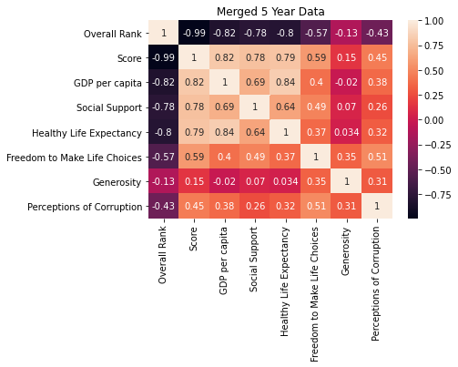

```python
correlation = merged.corr()
sn.heatmap(correlation, annot = True)
plt.title("Merged 5 Year Data")
plt.show()
```

# 5. Hypothesis testing and machine learning

Taking a closer look at the heat map generated above we can quickly notice that GDP per capita, social support, and healthy life expectancy have extremely high correlations with happiness score. This suggests that these variables might be correlated to each other.

The correlation between GDP per capita, social support, and healthy life expectancy are extremely high.

This presents an issue in creating a multi-variable linear regression model. Since the predictor variables are highly correlated the precision of estimated regression coefficient decreases. By using highly correlated predictors in a regression model we are effectively increasing the standard error and overfitting our model to our data set. Thus we will examine some linear regression models and apply the most effective model to out data set.

First we apply a multi-variable linear regression model with the predicto variables: GDP per Capita, Healthy Life Expectancy and Social Support.

```python
X = merged[['GDP per capita', 'Healthy Life Expectancy', 'Social Support']]
y = merged['Score']

regr = linear_model.LinearRegression()
regr.fit(X,y)

mod = sm.OLS(y,X)
model_fit = mod.fit()
print(model_fit.summary())
```

```
                                 OLS Regression Results
=======================================================================================
Dep. Variable:                  Score   R-squared (uncentered):                   0.984
Model:                            OLS   Adj. R-squared (uncentered):              0.984
Method:                 Least Squares   F-statistic:                              2863.
Date:                Sun, 16 May 2021   Prob (F-statistic):                   5.08e-124
Time:                        16:41:52   Log-Likelihood:                         -149.10
No. Observations:                 141   AIC:                                      304.2
Df Residuals:                     138   BIC:                                      313.1
Df Model:                           3
Covariance Type:            nonrobust
===========================================================================================
                              coef    std err          t      P>|t|      [0.025      0.975]
-------------------------------------------------------------------------------------------
GDP per capita              0.2912      0.292      0.996      0.321      -0.287       0.869
Healthy Life Expectancy     2.3059      0.487      4.739      0.000       1.344       3.268
Social Support              3.2906      0.212     15.520      0.000       2.871       3.710
==============================================================================
Omnibus:                        3.678   Durbin-Watson:                   1.921
Prob(Omnibus):                  0.159   Jarque-Bera (JB):                3.153
Skew:                           0.305   Prob(JB):                        0.207
Kurtosis:                       3.405   Cond. No.                         14.9
==============================================================================

Notes:
[1] R² is computed without centering (uncentered) since the model does not contain a constant.
[2] Standard Errors assume that the covariance matrix of the errors is correctly specified.
```

Examining this model we find that the Adjusted R-Squared value is extremely high, which means that this model fits our data very well. However, as we further examine the model we run into some issues. As we predicted above, the model is over fitting our data. Examining the P values we find that the p-value for GDP per capita is extremely high (.321) and our standard error across the three variables are also very high. The high correlation between the three predictor variables is fitting our data extremely well, which makes for a useless predictior.

Since using the three variables was not effective in generating a good model, we will examine the past table and attempt to generate a model that is more effective in predicting overall happiness. The heat map above showed that Healthy life Expectancy and social support had the lowest correlation, so lets analyze this as a model:

```python
X = merged[['Healthy Life Expectancy', 'Social Support']]
y = merged['Score']

regr = linear_model.LinearRegression()
regr.fit(X,y)

mod = sm.OLS(y,X)
model_fit = mod.fit()
print(model_fit.summary())
```

```
                                 OLS Regression Results
=======================================================================================
Dep. Variable:                  Score   R-squared (uncentered):                   0.984
Model:                            OLS   Adj. R-squared (uncentered):              0.984
Method:                 Least Squares   F-statistic:                              4294.
Date:                Sun, 16 May 2021   Prob (F-statistic):                   1.12e-125
Time:                        16:41:54   Log-Likelihood:                         -149.61
No. Observations:                 141   AIC:                                      303.2
Df Residuals:                     139   BIC:                                      309.1
Df Model:                           2
Covariance Type:            nonrobust
===========================================================================================
                              coef    std err          t      P>|t|      [0.025      0.975]
-------------------------------------------------------------------------------------------
Healthy Life Expectancy     2.6475      0.345      7.671      0.000       1.965       3.330
Social Support              3.3458      0.205     16.348      0.000       2.941       3.750
==============================================================================
Omnibus:                        3.595   Durbin-Watson:                   1.899
Prob(Omnibus):                  0.166   Jarque-Bera (JB):                3.070
Skew:                           0.301   Prob(JB):                        0.215
Kurtosis:                       3.399   Cond. No.                         8.74
==============================================================================

Notes:
[1] R² is computed without centering (uncentered) since the model does not contain a constant.
[2] Standard Errors assume that the covariance matrix of the errors is correctly specified.
```

Once again, we can clearly see that the model fits our data extremely well with an adjusted R-squared value of .984. However, the standad errors are extremely high. This indicates that our model does not perform well as a predictor.

From the above trials, we notice that the correlation between the variables is way too high and causing a lot of interaction between each other and negatively affecting our model. We will now take a look at a regression model using only the predictor variable GDP Per Capita since it had the highest correlation to happiness score.

```python
X = merged[['GDP per capita']]
y = merged['Score']

regr = linear_model.LinearRegression()
regr.fit(X,y)

mod = sm.OLS(y,X)
model_fit = mod.fit()
print(model_fit.summary())
```

```
                                 OLS Regression Results
=======================================================================================
Dep. Variable:                  Score   R-squared (uncentered):                   0.935
Model:                            OLS   Adj. R-squared (uncentered):              0.934
Method:                 Least Squares   F-statistic:                              2003.
Date:                Sun, 16 May 2021   Prob (F-statistic):                    7.89e-85
Time:                        16:41:57   Log-Likelihood:                         -249.10
No. Observations:                 141   AIC:                                      500.2
Df Residuals:                     140   BIC:                                      503.2
Df Model:                           1
Covariance Type:            nonrobust
==================================================================================
                     coef    std err          t      P>|t|      [0.025      0.975]
----------------------------------------------------------------------------------
GDP per capita     5.2947      0.118     44.757      0.000       5.061       5.529
==============================================================================
Omnibus:                        4.441   Durbin-Watson:                   1.610
Prob(Omnibus):                  0.109   Jarque-Bera (JB):                3.467
Skew:                           0.264   Prob(JB):                        0.177
Kurtosis:                       2.442   Cond. No.                         1.00
==============================================================================

Notes:
[1] R² is computed without centering (uncentered) since the model does not contain a constant.
[2] Standard Errors assume that the covariance matrix of the errors is correctly specified.
```

At a first glance we notice that this model yields an adjusted R-squared value of .934, a P-value of 0.000 and a standard error of .118. These values indicate that this linear regression model performs extremely well. The high R-squared value shows that the model fits our data very nicely, and the error (while still a bit high, is much better).

Now as an attempt to further improve our model, we will add variables that had a high correlation to each other but not a significant correlation with GDP per capita.

```python
X = merged[['GDP per capita','Freedom to Make Life Choices','Generosity']]
y = merged['Score']

regr = linear_model.LinearRegression()
regr.fit(X,y)

mod = sm.OLS(y,X)
model_fit = mod.fit()
print(model_fit.summary())
```

```
                                 OLS Regression Results
=======================================================================================
Dep. Variable:                  Score   R-squared (uncentered):                   0.974
Model:                            OLS   Adj. R-squared (uncentered):              0.974
Method:                 Least Squares   F-statistic:                              1745.
Date:                Sun, 16 May 2021   Prob (F-statistic):                   1.73e-109
Time:                        16:41:59   Log-Likelihood:                         -183.30
No. Observations:                 141   AIC:                                      372.6
Df Residuals:                     138   BIC:                                      381.4
Df Model:                           3
Covariance Type:            nonrobust
================================================================================================
                                   coef    std err          t      P>|t|      [0.025      0.975]
------------------------------------------------------------------------------------------------
GDP per capita                   2.8399      0.194     14.657      0.000       2.457       3.223
Freedom to Make Life Choices     4.8136      0.570      8.443      0.000       3.686       5.941
Generosity                       2.7136      0.658      4.122      0.000       1.412       4.015
==============================================================================
Omnibus:                        0.824   Durbin-Watson:                   1.877
Prob(Omnibus):                  0.662   Jarque-Bera (JB):                0.946
Skew:                          -0.139   Prob(JB):                        0.623
Kurtosis:                       2.711   Cond. No.                         11.6
==============================================================================

Notes:
[1] R² is computed without centering (uncentered) since the model does not contain a constant.
[2] Standard Errors assume that the covariance matrix of the errors is correctly specified.
```

The inclusion of these two variables increased the adjusted R-squared of the model. However this improvement of R-squared is not worth the additional standard error that we receive from the inclusion of these two variables. The standard error for the two additional variables are .57 and .66, which are way too high. They also cause the standard error of GDP per capita to increase to .194. This model fails to be a good predictor, and overfits our dataset.

Overall we found that the best linear regression model for predicting Happiness score is Score Vs. GDP Per Capita. This model yields a very high R-squared value at a very small standard error. This actually makes perfect sense, GDP Per Capita is highly correlated to most of the other variables. Developed countries tend to have the highest GDP which in turn cause a lower perception of corruption, higher life expectancy... All of the other variables are highly correlated to GDP Per Capita. Using highly correlated variables introduce a significant amount of error to the model, since we don't know how much of the change in the model is truly attributed to change of GDP per capita.

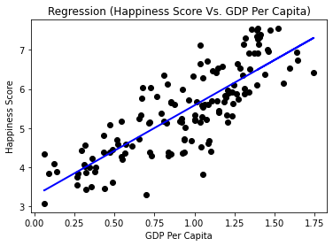

```python
X = merged[['GDP per capita']]
y = merged['Score']

regr = linear_model.LinearRegression()
regr.fit(X,y)
ypred = regr.predict(X)

plt.title('Regression (Happiness Score Vs. GDP Per Capita)')
plt.ylabel('Happiness Score')
plt.xlabel('GDP Per Capita')
plt.scatter(X, y, color='black')
plt.plot(X, ypred, color='blue', linewidth=2)
plt.show()
```

# 4.5 Food for Thought

Previously, GDP, Social Support, and Life Expectancy were all very close in correlation to happiness score, and it was difficult to differentiate them. While still close, GDP per capita slightly edges the other two out and is likely the strongest factor in determining happiness for a nation.

While this is interesting, looking at how a nation's happiness can change seems very prudent given society's currrent chase of "happiness". It can give a better sense of how sensitive happiness can be to the factors polled. Let's look at nations who have changed in ranking between 2015 and 2019.

```python
intersection = list(set(data_15['Country or Region']) & set(data_19['Country or Region']))
#Will define difference as 2019 ranking - 2015 ranking
```

```python
differences = pd.DataFrame(columns = ['Rank Difference', 'Country or Region', 'Score Diff', 'GDP Diff', 'Social Diff', 'LE Diff',
                 'Freedom Diff', 'Generosity Diff', 'Corruption Diff'])

for country in intersection:
    rank_diff = int(data_19.loc[data_19['Country or Region'] == country, 'Overall Rank']) - int(data_15.loc[data_15['Country or Region'] == country, 'Overall Rank'])
    score_diff = float(data_19.loc[data_19['Country or Region'] == country, 'Score']) - float(data_15.loc[data_15['Country or Region'] == country, 'Score'])
    gdp_diff = float(data_19.loc[data_19['Country or Region'] == country, 'GDP per capita']) - float(data_15.loc[data_15['Country or Region'] == country, 'GDP per capita'])
    social_diff = float(data_19.loc[data_19['Country or Region'] == country, 'Social Support']) - float(data_15.loc[data_15['Country or Region'] == country, 'Social Support'])
    le_diff = float(data_19.loc[data_19['Country or Region'] == country, 'Healthy Life Expectancy']) - float(data_15.loc[data_15['Country or Region'] == country, 'Healthy Life Expectancy'])
    freedom_diff = float(data_19.loc[data_19['Country or Region'] == country, 'Freedom to Make Life Choices']) - float(data_15.loc[data_15['Country or Region'] == country, 'Freedom to Make Life Choices'])
    gen_diff = float(data_19.loc[data_19['Country or Region'] == country, 'Generosity']) - float(data_15.loc[data_15['Country or Region'] == country, 'Generosity'])
    corruption_diff = float(data_19.loc[data_19['Country or Region'] == country, 'Perceptions of Corruption']) - float(data_15.loc[data_15['Country or Region'] == country, 'Perceptions of Corruption'])

    to_add = pd.DataFrame([[rank_diff, country, score_diff, gdp_diff, social_diff, le_diff, freedom_diff, gen_diff, corruption_diff]],
                          columns = ['Rank Difference', 'Country or Region', 'Score Diff', 'GDP Diff', 'Social Diff', 'LE Diff',
                                     'Freedom Diff', 'Generosity Diff', 'Corruption Diff'])
    differences = differences.append(to_add, ignore_index=True)
```

```python
differences = differences.sort_values(by=['Rank Difference'], ascending=True)
differences.head(5)
```

|  | Rank Difference | Country or Region | Score Diff | GDP Diff | Social Diff | LE Diff | Freedom Diff | Generosity Diff | Corruption Diff |
| --- | --- | --- | --- | --- | --- | --- | --- | --- | --- |
| 21 | -53 | Benin | 1.543 | 0.10635 | 0.08314 | 0.07790 | -0.13550 | -0.00760 | 0.00190 |
| 94 | -52 | Ivory Coast | 1.289 | 0.10366 | 0.03685 | 0.08015 | -0.11666 | -0.04765 | -0.08922 |
| 63 | -46 | Honduras | 1.072 | 0.04668 | 0.28252 | 0.13290 | 0.10552 | 0.01573 | 0.00975 |
| 87 | -42 | Hungary | 0.958 | 0.08006 | 0.20785 | 0.06895 | -0.12212 | -0.04700 | -0.00758 |
| 135 | -39 | Gabon | 0.903 | -0.00324 | 0.27772 | 0.13728 | -0.02414 | -0.02522 | -0.05591 |

```python
differences.tail(5)
```

|  | Rank Difference | Country or Region | Score Diff | GDP Diff | Social Diff | LE Diff | Freedom Diff | Generosity Diff | Corruption Diff |
| --- | --- | --- | --- | --- | --- | --- | --- | --- | --- |
| 116 | 31 | Zimbabwe | -0.947 | 0.09500 | 0.08124 | 0.09825 | 0.10239 | -0.03887 | 0.00821 |
| 9 | 34 | Swaziland | -0.655 | 0.09894 | 0.07616 | -0.07566 | 0.00642 | -0.10859 | 0.10440 |
| 51 | 47 | Lesotho | -1.096 | 0.11355 | 0.12797 | 0.09188 | 0.04133 | -0.05688 | -0.03204 |
| 29 | 53 | Zambia | -1.022 | 0.10762 | 0.14188 | 0.12676 | -0.05727 | 0.05109 | -0.03768 |
| 11 | 85 | Venezuela | -2.103 | -0.08424 | 0.17104 | 0.08448 | -0.27508 | 0.00559 | -0.06369 |

Because it's 2019-2015, that means a negative rank is actually good, as that means rank decreased, with 1 being the best. Let's look at manual comparisons for 2019 vs. 2015 at a few at the top/bottom of the rank changes.

```python
data_19[data_19['Country or Region'] == 'Venezuela']
```

|  | Overall Rank | Country or Region | Score | GDP per capita | Social Support | Healthy Life Expectancy | Freedom to Make Life Choices | Generosity | Perceptions of Corruption | Year |
| --- | --- | --- | --- | --- | --- | --- | --- | --- | --- | --- |
| 107 | 108 | Venezuela | 4.707 | 0.96 | 1.427 | 0.805 | 0.154 | 0.064 | 0.047 | 2019 |

```python
data_15[data_15['Country or Region'] == 'Venezuela']
```

|  | Overall Rank | Country or Region | Score | GDP per capita | Social Support | Healthy Life Expectancy | Freedom to Make Life Choices | Generosity | Perceptions of Corruption | Year |
| --- | --- | --- | --- | --- | --- | --- | --- | --- | --- | --- |
| 22 | 23 | Venezuela | 6.81 | 1.04424 | 1.25596 | 0.72052 | 0.42908 | 0.05841 | 0.11069 | 2015 |

```python
data_19[data_19['Country or Region'] == 'Benin']
```

|  | Overall Rank | Country or Region | Score | GDP per capita | Social Support | Healthy Life Expectancy | Freedom to Make Life Choices | Generosity | Perceptions of Corruption | Year |
| --- | --- | --- | --- | --- | --- | --- | --- | --- | --- | --- |
| 101 | 102 | Benin | 4.883 | 0.393 | 0.437 | 0.397 | 0.349 | 0.175 | 0.082 | 2019 |

```python
data_15[data_15['Country or Region'] == 'Benin']
```

|  | Overall Rank | Country or Region | Score | GDP per capita | Social Support | Healthy Life Expectancy | Freedom to Make Life Choices | Generosity | Perceptions of Corruption | Year |
| --- | --- | --- | --- | --- | --- | --- | --- | --- | --- | --- |
| 154 | 155 | Benin | 3.34 | 0.28665 | 0.35386 | 0.3191 | 0.4845 | 0.1826 | 0.0801 | 2015 |

```python
data_19[data_19['Country or Region'] == 'Zambia']
```

|  | Overall Rank | Country or Region | Score | GDP per capita | Social Support | Healthy Life Expectancy | Freedom to Make Life Choices | Generosity | Perceptions of Corruption | Year |
| --- | --- | --- | --- | --- | --- | --- | --- | --- | --- | --- |
| 137 | 138 | Zambia | 4.107 | 0.578 | 1.058 | 0.426 | 0.431 | 0.247 | 0.087 | 2019 |

```python
data_15[data_15['Country or Region'] == 'Zambia']
```

|  | Overall Rank | Country or Region | Score | GDP per capita | Social Support | Healthy Life Expectancy | Freedom to Make Life Choices | Generosity | Perceptions of Corruption | Year |
| --- | --- | --- | --- | --- | --- | --- | --- | --- | --- | --- |
| 84 | 85 | Zambia | 5.129 | 0.47038 | 0.91612 | 0.29924 | 0.48827 | 0.19591 | 0.12468 | 2015 |

Looking at how drastically some countries changed ranks, let's see how the variable correlation for countries that increased in happiness, and those that decreased in happiness differ.

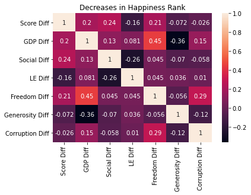

```python
#remember this is using rank difference, 2019-2015 rank.
positive = differences[differences['Rank Difference'] >= 0]
correlation = positive.corr()
sn.heatmap(correlation, annot = True)
plt.title("Decreases in Happiness Rank")
plt.show()
```

This is quite different to the initial heatmaps generated. This would indicate that the strongest factors that despite increases in GDP, Social Support, and Freedom are correlated with DECREASES in happiness. Life Expectancy bucked the trend of the 3 previously enterwtined variables (GDP, social, life expectancy) and actually increased despite happiness decreasing. This could maybe be explained by technology advancing or modern healthcare being more prevalent/expanded throughout the world (e.g. Bill Gates fighting malaria). While these things should probably be further examined, this tutorial simply lacks the data to make any stronger, more meaningful analysis.

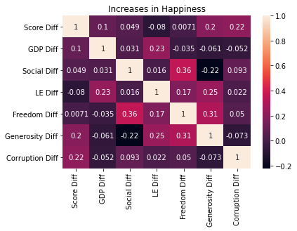

```python
negative = differences[differences['Rank Difference'] <= 0]
correlation = negative.corr()
sn.heatmap(correlation, annot = True)
plt.title("Increases in Happiness")
plt.show()
```

This heatmap should indicate factors for countries that are now MORE happy. Again, it seems to tell a different tale than the initial heatmaps. This would indicate that countries that became happier gained some GDP, but the stronger predictors for becoming more happy is decreases in perceived corruption, and increases in generosity. Obviously more money is always helpful, but larger systemic changes like decreases in corruption led to more happiness gains. This could maybe be explained by the countries did already have a requisite amount of wealth and other factors, and instead individuals needed to begin cultivating their own happiness. It's difficult to gain anything more meaningful, but this could warrant further exploration.

# 6. Conclusions

[output not shown]

# Links:

Here are some links regarding the methods used that could be helpful:

1. Heatmaps: https://seaborn.pydata.org/generated/seaborn.heatmap.html
2. Interactive map for countries: https://python-visualization.github.io/folium/
3. Linear Regression: https://www.statsmodels.org/dev/examples/notebooks/generated/ols.html